# Kaggle Competition: KKBox’s Music Recommendation Challenge

YX.Wang

The music streaming service company *KKBOX* held two competitions on *KAGGLE* earlier.One is a regression problem and another is a classification problem.The competition I took (the later one) requires participants to predict the probability of a user listening to a song repetitively after the first observable listening event.

Outline:

- A quick EDA and data preprocessing.
- Feature engineering.
- Training the model.

### Package loading, data importing and data merging

In the data preprocessing and data manipulation part,I will use package `data.table` as my main tool since it’s more efficient when handling large data frame.

First,we need three consecutive left-join operations to construct our main data frame.The primary key is *msno* (member id) and *song_id*.

```r
all <- rbind.fill(train,test)

all_members <- members[all,on="msno"]
all_song <- song[all_members,on="song_id"]
all_all <- song_ex[all_song,on="song_id"]
```

Let’s take a glance at the data,you can scroll the x-axis bar to see every variables in data:

|  | song_id | name | isrc | song_length | genre_ids | artist_name | composer | lyricist | language | msno | city | bd | gender | registered_via | registration_init_time | expiration_date | source_system_tab | source_screen_name | source_type | target | id |
| --- | --- | --- | --- | --- | --- | --- | --- | --- | --- | --- | --- | --- | --- | --- | --- | --- | --- | --- | --- | --- | --- |
| 1 | BBzumQNXUHKdEBOB7mAJuzok+IJA1c2Ryg/yzTF6tik= | Good Grief | GBUM71602854 | 206471 | 359 | Bastille | Dan Smith\| Mark Crew |  | 52 | FGtllVqz18RPiwJj/edr2gV78zirAiY/9SmYvia+kCg= | 1 | 0 |  | 7 | 20120102 | 20171005 | explore | Explore | online-playlist | 1 |  |
| 2 | bhp/MpSNoqoxOIB+/l8WPqu6jldth4DIpCm3ayXnJqM= | Lords of Cardboard | US3C69910183 | 284584 | 1259 | Various Artists |  |  | 52 | Xumu+NIjS6QYVxDS4/t3SawvJ7viT9hPKXmf0RtLNx8= | 13 | 24 | female | 9 | 20110525 | 20170911 | my library | Local playlist more | local-playlist | 1 |  |
| 3 | JNWfrrC7zNN7BdMpsISKa4Mw+xVJYNnxXh3/Epw7QgY= | Hip Hop Is Dead(Album Version (Edited)) | USUM70618761 | 225396 | 1259 | Nas | N. Jones、W. Adams、J. Lordan、D. Ingle |  | 52 | Xumu+NIjS6QYVxDS4/t3SawvJ7viT9hPKXmf0RtLNx8= | 13 | 24 | female | 9 | 20110525 | 20170911 | my library | Local playlist more | local-playlist | 1 |  |
| 4 | 2A87tzfnJTSWqD7gIZHisolhe4DMdzkbd6LzO1KHjNs= | Disco Africa | GBUQH1000063 | 255512 | 1019 | Soundway | Kwadwo Donkoh |  | -1 | Xumu+NIjS6QYVxDS4/t3SawvJ7viT9hPKXmf0RtLNx8= | 13 | 24 | female | 9 | 20110525 | 20170911 | my library | Local playlist more | local-playlist | 1 |  |
| 5 | 3qm6XTZ6MOCU11x8FIVbAGH5l5uMkT3/ZalWG1oo2Gc= | Sleep Without You | QM3E21606003 | 187802 | 1011 | Brett Young | Brett Young\| Kelly Archer\| Justin Ebach |  | 52 | FGtllVqz18RPiwJj/edr2gV78zirAiY/9SmYvia+kCg= | 1 | 0 |  | 7 | 20120102 | 20171005 | explore | Explore | online-playlist | 1 |  |
| 6 | 3Hg5kugV1S0wzEVLAEfqjIV5UHzb7bCrdBRQlGygLvU= | Panda | USUM71601094 | 247803 | 1259 | Desiigner | Sidney Selby\| Adnan Khan |  | 52 | FGtllVqz18RPiwJj/edr2gV78zirAiY/9SmYvia+kCg= | 1 | 0 |  | 7 | 20120102 | 20171005 | explore | Explore | online-playlist | 1 |  |
| 7 | VkILU0H1h3NMmk9MQrXouNudGk5n8Ls5cqRRuBxeTh4= | 眼\| 鼻\| 口 (Eyes\| Nose\| Lips) | TWA531400512 | 229982 | 465 | BIGBANG TAEYANG | TEDDY\| DEE.P\| Rebecca Johnson | TEDDY\| TAEYANG | 31 | Xumu+NIjS6QYVxDS4/t3SawvJ7viT9hPKXmf0RtLNx8= | 13 | 24 | female | 9 | 20110525 | 20170911 | my library | Local playlist more | local-playlist | 1 |  |
| 8 | bPIvRTzfHxH5LgHrStll+tYwSQNVV8PySgA3M1PfTgc= | Star Of The Show | USLXJ1607334 | 181115 | 1011 | Thomas Rhett | Thomas Rhett\| Rhett Akins\| Ben Hayslip |  | 52 | FGtllVqz18RPiwJj/edr2gV78zirAiY/9SmYvia+kCg= | 1 | 0 |  | 7 | 20120102 | 20171005 | explore | Explore | online-playlist | 1 |  |
| 9 | /bU6IRSK+YNlNbaTkxo7bhsb2EDLPrnksdX3ggcZNhI= | Dreaming Out Loud | USUM70759544 | 278964 | 2022 | OneRepublic | Ryan Tedder |  | 52 | uHqAtShXTRXju5GE8ri3ITsVFepPf8jUoCF7ffNOuqE= | 15 | 26 | male | 9 | 20111107 | 20180304 | my library | Local playlist more | local-library | 1 |  |
| 10 | EbI7xoNxI+3QSsiHxL13zBdgHIJOwa3srHd7cDcnJ0g= | Counting Stars | USUM71301306 | 257369 | 465 | OneRepublic | Ryan Tedder |  | 52 | uHqAtShXTRXju5GE8ri3ITsVFepPf8jUoCF7ffNOuqE= | 15 | 26 | male | 9 | 20111107 | 20180304 | my library | Local playlist more | local-library | 1 |  |

[output cut: 90 more lines]

###EDA

First of all,we would like to do some very basic features explorations in order to get the sense of data’s structure.Since not every predictors are suitable for visualizing, we excluded them only for the plotting’s sack.

```r
all_explore <- all_all %>%
  filter(!is.na(target)) %>%
  select(song_length,genre_ids,language,city,gender,registered_via,source_system_tab,source_screen_name,source_type) %>%
  data.table

ano <- anomalies(all_explore)
ano$variables
```

```
##             Variable       q     qNA    pNA qZero pZero qBlank pBlank qInf
## 1             gender 7377418 2961479 40.14%     0     -      0      -    0
## 2 source_screen_name 7377418  414804  5.62%     0     -      0      -    0
## 3          genre_ids 7377418  118455  1.61%     0     -      0      -    0
## 4        source_type 7377418   21539  0.29%     0     -      0      -    0
## 5  source_system_tab 7377418   18371  0.25%     0     -      0      -    0
## 6           language 7377418     150     0%     0     -      0      -    0
## 7        song_length 7377418     114     0%     0     -      0      -    0
## 8     registered_via 7377418       0      -     0     -      0      -    0
## 9               city 7377418       0      -     0     -      0      -    0
##   pInf qDistinct      type anomalous_percent
## 1    -         3 Character            40.14%
## 2    -        21 Character             5.62%
## 3    -       573 Character             1.61%
## 4    -        13 Character             0.29%
## 5    -        10 Character             0.25%
## 6    -        11   Numeric                0%
## 7    -     60267   Integer                0%
## 8    -         5   Integer                 -
## 9    -        21   Integer                 -
```

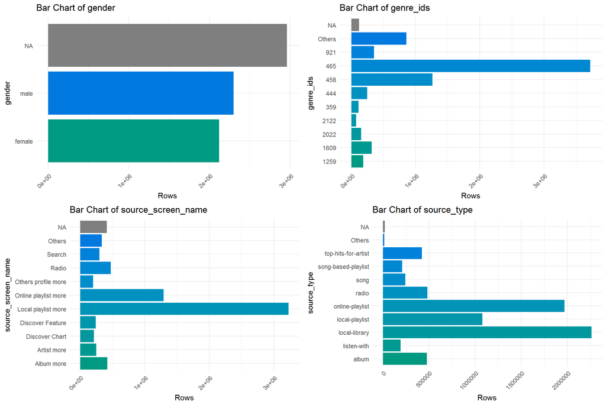

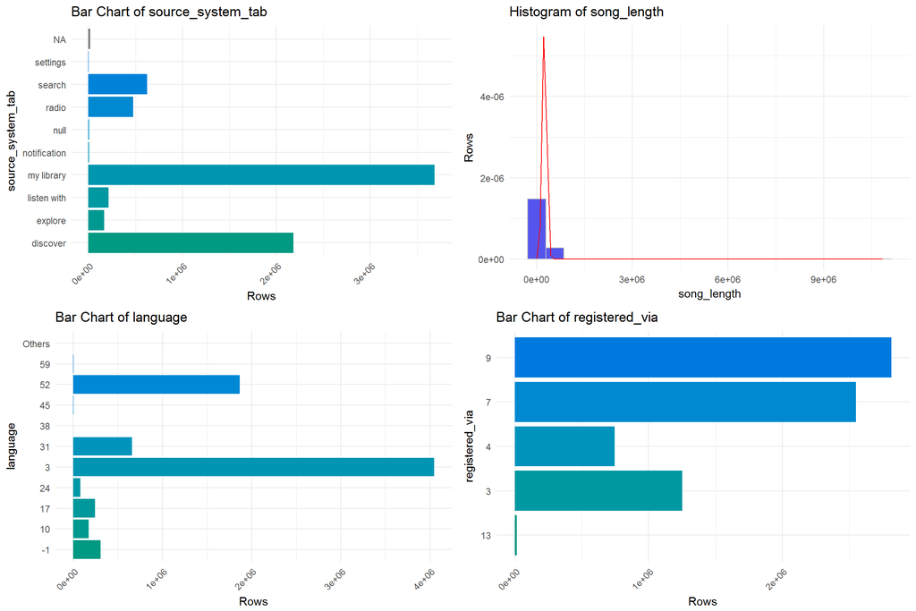

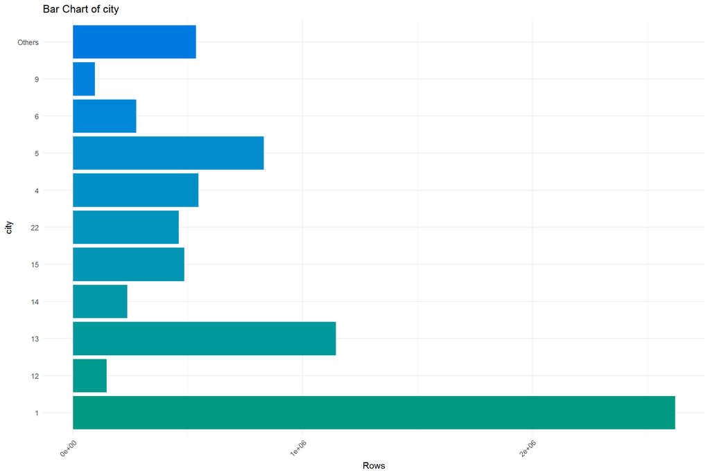

```
##      Variable    p_1   p_10   p_25   p_50   p_75   p_90   p_99
## 1 song_length 109087 191518 214726 241812 272160 298260 395947
```

```r
cat_list_exp <- names(all_explore)[-1]
all_explore[,(cat_list_exp):= lapply(.SD, factor),.SDcols=cat_list_exp]

distributions(all_explore)
```

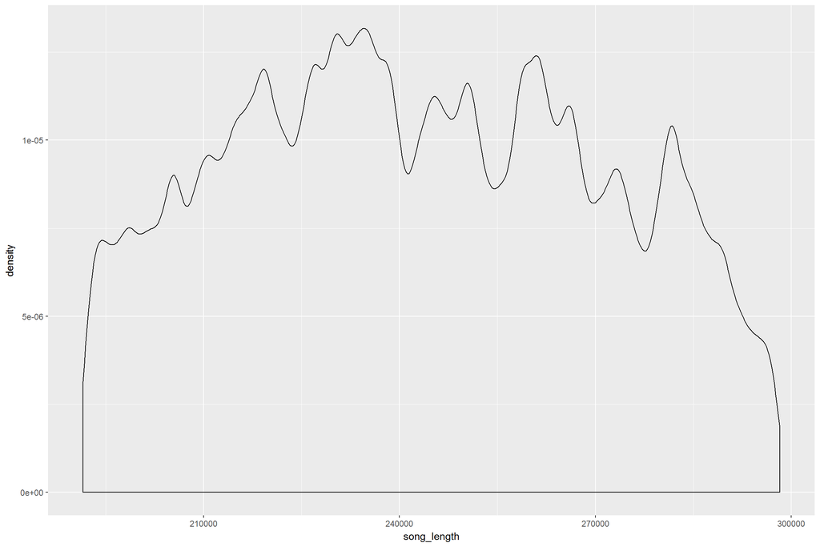

```r
length <- ggplot(all_explore %>%
                  filter(song_length>quantile(song_length,0.1,na.rm=T)&                         song_length<quantile(song_length,0.9,na.rm=T)),
                 aes(x=song_length)) +
  geom_density()

length
```

```r
rm(all_explore,ano,length);gc()
```

```
##             used   (Mb) gc trigger   (Mb)   max used   (Mb)
## Ncells   6857478  366.3    9968622  532.4    9968622  532.4
## Vcells 611085830 4662.3 1100696678 8397.7 1100692504 8397.7
```

When looking at the features,some very direct conjectures arise: **what’s the relation of three seemly informative variables (e.g. source_system_tab, source_screen_name and source_type) and target?**

For convenience sake, let’s define the fuction first.The function will count the number of observations in one column’s each class, then make the results visualizable!

```r
target_vs_column <-function(df, col_name, x , y, title)
                  {
                  temp_df <- df %>%
                          group_by_(col_name) %>%
                          summarize(count=n(), mean_target=mean(target)) %>%
                          arrange(desc(mean_target))

                  df_plot <- temp_df %>%
                            ggplot(aes_string(col_name,"mean_target")) +
                            geom_col(aes(fill=count)) +
                            scale_fill_gradient(low='lightskyblue', high='pink2')+
                            coord_flip() +
                            labs(x=x,
                                 y=y,
                                 title=title)

                  print(df_plot)
                  return (temp_df)
}
```

OK, time for printing them out.

#### *Source_system_tab* v.s. *Target*

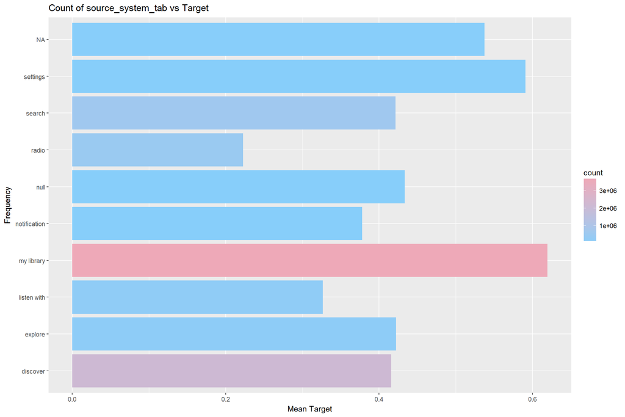

```
## # A tibble: 10 x 3
##    source_system_tab   count mean_target
##                <chr>   <int>       <dbl>
##  1        my library 3684730   0.6196590
##  2          settings    2200   0.5909091
##  3              <NA>   18371   0.5374231
##  4              null    6478   0.4336215
##  5           explore  167949   0.4221460
##  6            search  623286   0.4213619
##  7          discover 2179252   0.4157697
##  8      notification    6185   0.3780113
##  9       listen with  212266   0.3265808
## 10             radio  476701   0.2226616
```

```r
target_vs_column(all_all %>% filter(!is.na(target)),
                  col_name="source_system_tab",
                  x='Frequency',
                  y='Mean Target',
                  title='Count of source_system_tab vs Target')
```

Not supriseingly,users tend to replay songs that listen via *my library*.If yor do restore some songs in your local library, you must really love them! On the other hand,radio is a random shuffle of songs and hence it leads to low mean_target.

#### *Source_screen_name* v.s. *Target*

[figure not shown]

```
## # A tibble: 21 x 3
##     source_screen_name   count mean_target
##                  <chr>   <int>       <dbl>
##  1             Payment      12   0.6666667
##  2          My library   75980   0.6571729
##  3 Local playlist more 3228202   0.6369834
##  4   My library_Search    6451   0.6112231
##  5      Discover Chart  213658   0.5170319
##  6             Concert      47   0.5106383
##  7              Search  298487   0.4717492
##  8                <NA>  414804   0.4697881
##  9        Discover New   15955   0.4555312
## 10             Explore   72342   0.4481491
## # ... with 11 more rows
```

```r
target_vs_column(all_all %>% filter(!is.na(target)),
                  col_name="source_screen_name",
                  x='Frequency',
                  y='Mean Target',
                  title='Count of source_system_tab vs Target')
```

It seems very similar to above one, the layout related to the local library or local playlist have the hightest chance of replaying songs.

#### *Source_type* v.s. *Target*

[figure not shown]

```
## # A tibble: 13 x 3
##               source_type   count mean_target
##                     <chr>   <int>       <dbl>
##  1         local-playlist 1079503   0.6577193
##  2          local-library 2261399   0.6320981
##  3                 artist    3038   0.5727452
##  4                   <NA>   21539   0.5252333
##  5 topic-article-playlist   11194   0.4942827
##  6                   song  244722   0.4374596
##  7        online-playlist 1967924   0.4249854
##  8    top-hits-for-artist  423614   0.4185367
##  9                  album  477344   0.3934207
## 10    song-based-playlist  210527   0.3804595
## 11      my-daily-playlist     663   0.3755656
## 12            listen-with  192842   0.3196503
## 13                  radio  483109   0.2197351
```

```r
target_vs_column(all_all %>% filter(!is.na(target)),
                  col_name="source_type",
                  x='Frequency',
                  y='Mean Target',
                  title='Count of source_system_tab vs Target')
```

*source_type* means the entry point a user first plays music on mobile apps.Again, it acts similar pattern to the above ones.

The information that contribute by these three features seems consistent: users will replay the songs they really love and hence tend to restore these enchanting songs in their local library.

The next nature question are: **Can the popular songs attract users to replay more times?** and **Are the frequent users more likely to repeat songs?**

#### *Song popularity* v.s. *Target*

```r
target_vs_colcount <- function(df, col_name, x, y, title)
                    {
                    df %>%
                      group_by_(col_name) %>%
                      summarize(count=n(), mean_target=mean(target)) %>%
                      group_by(count) %>%
                      summarize(new_count=n(), avg_target=mean(mean_target)) %>%
                      rename(no_of_songs=new_count, occurence=count) %>%
                      print %>%
                      arrange(desc(avg_target)) %>%
                      print %>%
                      ggplot(aes(occurence, avg_target)) +
                      geom_point(color='peachpuff2') +
                      geom_smooth(color='firebrick1') +
                      labs(x=x,
                           y=y,
                           title=title)
}
```

The *occurance* means frequency of occurrence of a song.In brief, you can regard *occurance* as the popularity of the song and the no_of_songs as the number of songs that correponds to that occurance.

```r
target_vs_colcount(all_all %>% filter(!is.na(target)), "song_id", "Song Occurence", "Mean Target", "Song Occurence vs Target")
```

```
## # A tibble: 1,798 x 3
##    occurence no_of_songs avg_target
##        <int>       <int>      <dbl>
##  1         1      166766  0.3776309
##  2         2       48444  0.3787363
##  3         3       26319  0.3860202
##  4         4       16789  0.3852671
##  5         5       12023  0.3876071
##  6         6        9175  0.3898456
##  7         7        7165  0.3899312
##  8         8        6068  0.3931897
##  9         9        5078  0.3894797
## 10        10        4219  0.3944537
## # ... with 1,788 more rows
## # A tibble: 1,798 x 3
##    occurence no_of_songs avg_target
##        <int>       <int>      <dbl>
##  1      2752           1  0.8510174
##  2     13293           1  0.7941022
##  3     13973           1  0.7790024
##  4      6241           1  0.7655824
##  5     12855           1  0.7629716
##  6     11521           1  0.7626942
##  7     12004           1  0.7500833
##  8     10565           1  0.7480360
##  9      9244           1  0.7465383
## 10     11835           1  0.7418673
## # ... with 1,788 more rows
```

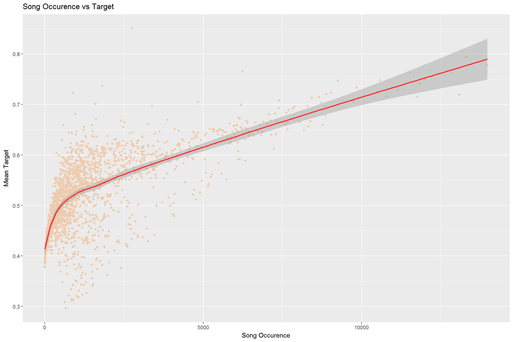

#### *Users’ frequncy* v.s. *Target*

```r
target_vs_colcount(all_all %>% filter(!is.na(target)), "msno", "User Occurence", "Mean Target", "User Occurence vs Target")
```

```
## # A tibble: 1,564 x 3
##    occurence no_of_songs avg_target
##        <int>       <int>      <dbl>
##  1         1         932  0.1620172
##  2         2         660  0.1643939
##  3         3         558  0.1296296
##  4         4         435  0.2120690
##  5         5         406  0.1768473
##  6         6         347  0.2055716
##  7         7         327  0.1896024
##  8         8         285  0.2078947
##  9         9         249  0.2190986
## 10        10         255  0.2607843
## # ... with 1,554 more rows
## # A tibble: 1,564 x 3
##    occurence no_of_songs avg_target
##        <int>       <int>      <dbl>
##  1      1109           1  0.9846709
##  2      1013           1  0.8795656
##  3      2091           1  0.8675275
##  4      1742           1  0.8628014
##  5       820           1  0.8548780
##  6      1081           1  0.8344126
##  7      1562           1  0.8341869
##  8      1522           1  0.8252300
##  9      1271           1  0.8221873
## 10      1039           1  0.8200192
## # ... with 1,554 more rows
```

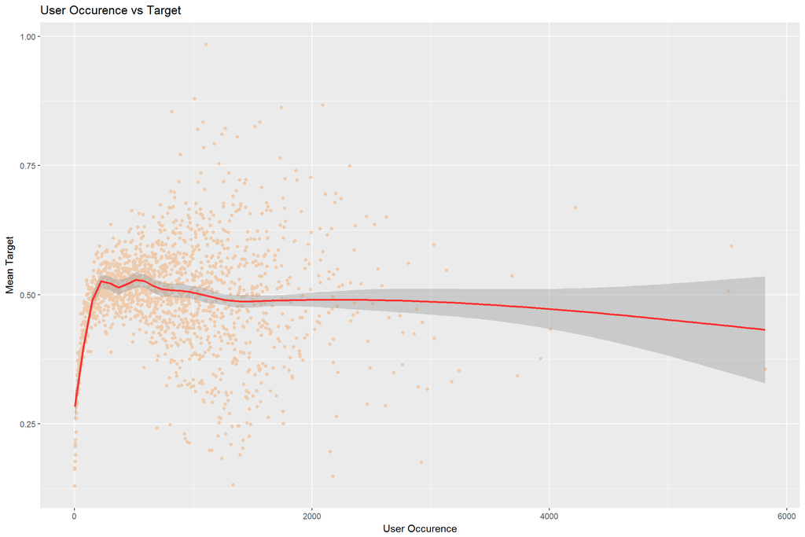

The trend is quite flat.It means there are not explicit connection betwen these two variables.A frequent user doesn’t stand for the higher chance of replay.

#### class balance of target

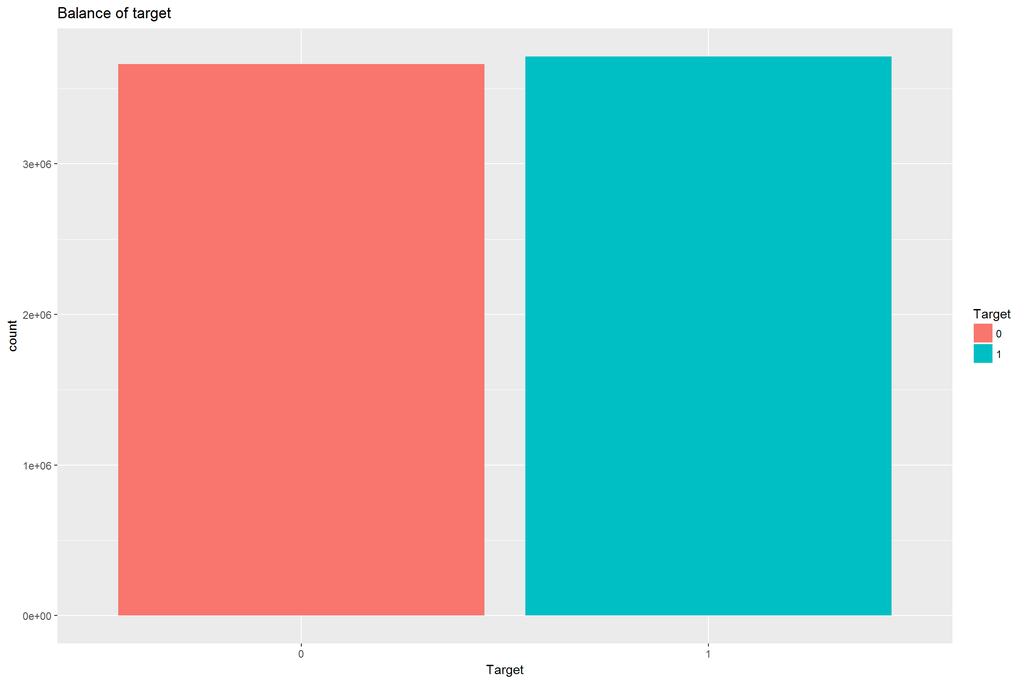

```r
all_all %>% filter(!is.na(target)) %>% select(target)%>%
                   ggplot(aes(factor(target),fill=factor(target)))+
  geom_bar()+
  labs(x="Target",title="Balance of target",fill="Target")
```

Very balanced class!We don’t need to do any under-sampling, over-sampling or SMOTE..etc.

#### Members’ characteristic

```r
members_colgroup <- function(df,col_name, x, y, title,xmin,xmax)
                    {
                    temp_df <- df %>%
                                  group_by_(col_name) %>%
                                  count() %>%
                                  arrange(desc(n))

                    df_plot <- temp_df %>%
                                    ggplot(aes_string(col_name, "n")) +
                                    geom_col(fill='firebrick1') +
                                    labs(x=x,
                                         y=y,
                                         title=title)+
                                    xlim(xmin, xmax)

                    print(df_plot)
                    return(temp_df)
}
```

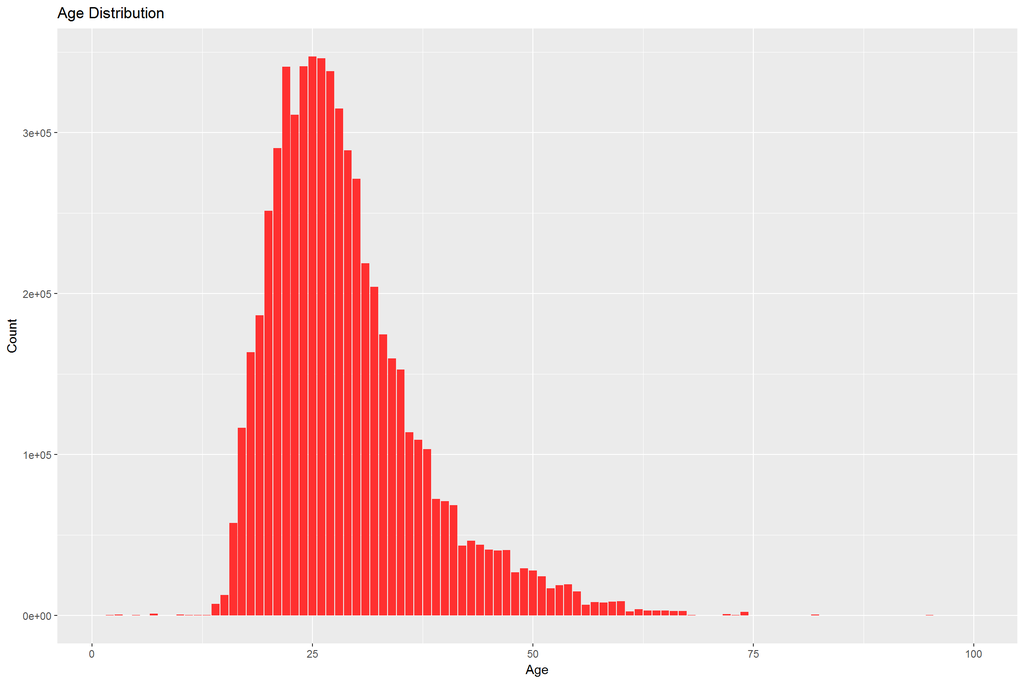

```
## # A tibble: 95 x 2
## # Groups:   bd [95]
##       bd       n
##    <int>   <int>
##  1     0 3983720
##  2    25  347373
##  3    26  346011
##  4    24  341249
##  5    22  340820
##  6    27  338138
##  7    28  314849
##  8    23  311035
##  9    21  290234
## 10    29  289018
## # ... with 85 more rows
```

```r
members_colgroup(all_all, "bd", "Age", "Count", "Age Distribution",1,100)
```

Most of the users are aged from 15 to 40, but there are some outliers may seem unreasonable.We should assess the rationality of this features.

```r
quantile(all_all$bd)
```

```
##   0%  25%  50%  75% 100%
##  -43    0   21   29 1051
```

```r
sum(all_all$bd==0)/nrow(all_all)
```

```
## [1] 0.4010103
```

```r
all_all$bd <- ifelse(all_all$bd==0,NA,all_all$bd)
all_all$bd <- ifelse(all_all$bd>80 | all_all$bd<6,NA,all_all$bd)
```

#### Missing values

The last part of EDA will be focus on the integrity of features.

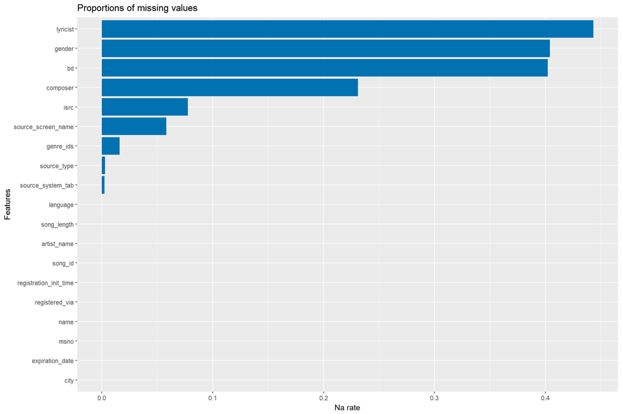

```r
na_rate <-
  all_all %>%
  select(-id,-target) %>%
  sapply(.,function(x) sum(is.na(x))/nrow(.)) %>%
  as.data.frame() %>%
  rownames_to_column(.,var="feature")

colnames(na_rate) <- c("feature","na.rate")

na_rate%>%
  ggplot(aes(x=reorder(feature,na.rate),y=na.rate))+
  geom_bar(stat="identity",fill="#0072B2")+
  labs(x ="Features",y ="Na rate",title="Proportions of missing values")+
  coord_flip()+
  theme_gray()
```

### Feature engineering

We’ll perform feature engineering in the order of songs’ attributes then members’ attributes.

#### Songs’ attributes

*ISRC* is the abbreviation of *International Standard Recording Code*.The first two characters mean *Country Code* and the sixth to seventh characters represent *Year of Reference*.

```r
all_all[,":="(record_country=substr(isrc,1,2),
              record_year=ifelse(as.numeric(substr(isrc,6,7))>17,
                            as.numeric(substr(isrc,6,7))+1900,
                            as.numeric(substr(isrc,6,7))+2000),
              name=NULL,
              isrc=NULL)
        ]
```

Furthermore, there are lots of features about songs were not consistently recorded, hence we can’t parse them perfectly.For example,the artist “姚中仁” is the same person of “MC Hotdog” so there are no systematic way to distinguish the numbers of composers of a song with composer “姚中仁 MC HotDog 陳昱榕 Ｅ-SO 周文傑 KENZY 林睦淵”.We tried to find as many patterns as possible, but again, not perfectly.

```r
all_all[,":="(num_lyr=str_count(lyricist,"\\| | \\/ | \\\\ | \\; | 、")+1,
         num_comp=str_count(composer,"\\| | \\/ | \\\\ | \\; | 、")+1,
         num_art=str_count(artist_name,"\\| | \\/ | \\\\ | \\; | 、")+1,
         is_ft=ifelse(grepl("ft\\.",artist_name) | grepl("feat",artist_name),"feat","non-feat"),
         art_comp_same=ifelse(artist_name==composer,"same","diff"),
         art_lyr_same=ifelse(artist_name==lyricist,"same","diff"),
         art_lyr_comp_same=ifelse(artist_name==lyricist & artist_name==composer & lyricist==composer,"same","diff"),
         long_short=ifelse(song_length>mean(song_length,na.rm=T),"long","short"))
        ]
```

#### Members’ attributes

```r
all_all[,":="(reg_year=substr(registration_init_time,1,4),
                reg_month=substr(registration_init_time,5,6),
                reg_day=substr(registration_init_time,7,8),
                exp_year=substr(expiration_date,1,4),
                exp_month=substr(expiration_date,5,6),
                exp_day=substr(expiration_date,7,8),
                duration=as.numeric(ymd(all_all$expiration_date)-ymd(all_all$registration_init_time)))
        ]
```

### Training

Before training models, we would like to mention about the reason why we choose *Lightgbm* as our tool.

Due to the high cardinality of predictors, one-hot-encoding which another famous GBM counterpart *XGBoost* requires should not be appropriate.Fortunately, *Lightgbm* can handle categorical features more theorically.

The next problem of data is the sparsity.Another lately-released GBM package *CatBoost* doesn’t support missing value handling.It just impute min or max from the dataset by now.

Base on the aboe two reasons, we decide to use *Lightgbn* as our solution.Just one step ahead of training part, we’ll convert all categorical features into class *factor*.

```r
cols_all <- c("source_system_tab",
               "source_screen_name",
               "source_type",
               "city",
               "gender",
               "registered_via",
               "genre_ids",
               "artist_name",
               "composer",
               "lyricist",
               "language",
               "reg_year",
               "reg_month",
               "exp_year",
               "exp_month",
               "reg_day",
               "exp_day",
               "record_country",
               "record_year",
               "is_ft",
               "art_comp_same",
               "art_lyr_same",
               "art_lyr_comp_same",
               "long_short"
)

all_all[,(cols_all):= lapply(.SD, factor),.SDcols=cols_all]
```

```r
all_all <- lgb.prepare2(all_all)

data_for_train_lgbm <- all_all %>%
  filter(!is.na(target)) %>%
  select(-song_id,
         -msno,
         -registration_init_time,
         -expiration_date
)
gb_train <- lgb.Dataset(data.matrix(data_for_train_lgbm %>% select(-target,-id)),
                       label = matrix(data_for_train_lgbm$target),
                       categorical_feature=c("song_length",
                                             "genre_ids",
                                             "artist_name",
                                             "composer",
                                             "lyricist",
                                             "language",
                                             "city",
                                             "gender",
                                             "registered_via",
                                             "source_system_tab",                                             "source_screen_name",
                                             "source_type",
                                             "reg_year",
                                             "reg_month",
                                             "exp_year",
                                             "exp_month",
                                             "reg_day",
                                             "exp_day",
                                             "record_country",
                                             "record_year",
                                             "is_ft",
                                             "art_comp_same",
                                             "art_lyr_same",
                                             "art_lyr_comp_same",
                                             "long_short"))


params.lgb = list(
  objective = "binary"
  , min_data_in_leaf = 10
  , feature_fraction = 0.8
  , bagging_fraction = 0.9
  , num_leaves = 64
  , max_depth = 8
  , lambda_l2 = 10
)


lgb_cv <- lgb.cv(
  params = params.lgb
  , data = gb_train
  , boosting = "gbdt"
  , nrounds = 50
  , eval = "auc"
  , early_stopping_rounds = 10
  , nfold = 10
  , learning_rate = 0.5
  , verbose = 1
  , stratified = TRUE
  , num_threads = 4
)
```

```
## [1]: valid's auc:0.674286+0.00118291
## [2]: valid's auc:0.685492+0.000849165
## [3]: valid's auc:0.690044+0.000429105
## [4]: valid's auc:0.693484+0.000684768
## [5]: valid's auc:0.696051+0.000744273
## [6]: valid's auc:0.698093+0.000917469
## [7]: valid's auc:0.700255+0.000982508
## [8]: valid's auc:0.701549+0.000588444
## [9]: valid's auc:0.703291+0.00103384
## [10]:    valid's auc:0.704216+0.000930754
## [11]:    valid's auc:0.704716+0.00114867
## [12]:    valid's auc:0.706069+0.000889864
## [13]:    valid's auc:0.706599+0.000906795
## [14]:    valid's auc:0.706939+0.00096234
## [15]:    valid's auc:0.707274+0.000856728
## [16]:    valid's auc:0.707791+0.00116748
## [17]:    valid's auc:0.708557+0.00119208
## [18]:    valid's auc:0.708705+0.00121326
## [19]:    valid's auc:0.709681+0.00131638
## [20]:    valid's auc:0.709876+0.00130619
## [21]:    valid's auc:0.710245+0.00121175
## [22]:    valid's auc:0.710432+0.00122062
## [23]:    valid's auc:0.711349+0.00129809
## [24]:    valid's auc:0.711996+0.00120665
## [25]:    valid's auc:0.712441+0.00131498
## [26]:    valid's auc:0.713227+0.0013908
## [27]:    valid's auc:0.714086+0.00162662
## [28]:    valid's auc:0.714266+0.00162601
## [29]:    valid's auc:0.714367+0.0016095
## [30]:    valid's auc:0.714835+0.00158165
## [31]:    valid's auc:0.715269+0.00154859
## [32]:    valid's auc:0.715788+0.00151077
## [33]:    valid's auc:0.715932+0.00160345
## [34]:    valid's auc:0.716152+0.00174533
## [35]:    valid's auc:0.716278+0.00174145
## [36]:    valid's auc:0.716801+0.00168903
## [37]:    valid's auc:0.717427+0.00185438
## [38]:    valid's auc:0.71819+0.00188258
## [39]:    valid's auc:0.718495+0.00196198
## [40]:    valid's auc:0.718733+0.00184255
## [41]:    valid's auc:0.719013+0.00171061
## [42]:    valid's auc:0.719581+0.00156742
## [43]:    valid's auc:0.71979+0.00168184
## [44]:    valid's auc:0.719828+0.0017016
## [45]:    valid's auc:0.720005+0.00174744
## [46]:    valid's auc:0.720314+0.00166816
## [47]:    valid's auc:0.720562+0.00153674
## [48]:    valid's auc:0.721194+0.00172581
## [49]:    valid's auc:0.721477+0.00176679
## [50]:    valid's auc:0.721619+0.00186204
```

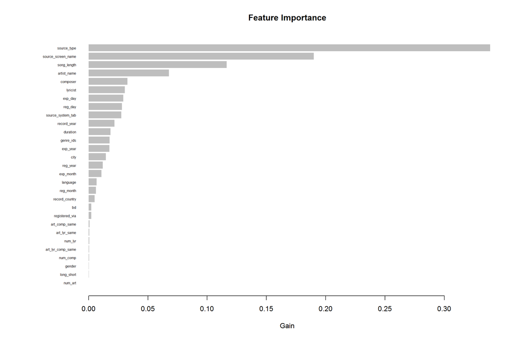

```r
lgb_model <- lgb.train(
  params = params.lgb
  , data = gb_train
  , learning_rate = 0.1
  , nrounds = 50
  , verbose = 1

)

imp <- lgb.importance(lgb_model,percentage=TRUE)
lgb.plot.importance(imp,top_n=32)
```